# Final Exam

Author

Ilana Berlin

Published

December 9, 2025

```r
library(tidyverse)
library(gt)
pressure <- read.csv("pressure.csv")
college <- read.csv("college.csv")
billboard <- read.csv("billboard.csv")
```

The first two problems use the `pressure` data set, the third and fourth use the `college` data set. Problem 5 uses the `billboard` data set from Tidy Tuesday[^1]

## Problem 1

> Is systolic blood pressure associated with lifestyle (urban/rural/suburban)? Test at significance level $\alpha = 0.5$ , following all standards and best-practices from class.

$H_0$: Mean systolic blood pressure is the same for all lifestyles.

$H_a$ Mean systolic blood pressure differs depending on lifestyle.

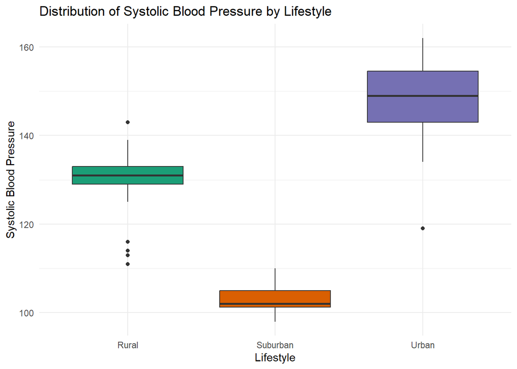

```r
pressure %>%
  ggplot(aes(x = lifestyle,
             y = systolic,
             fill = lifestyle)) +
  geom_boxplot(show.legend = FALSE) +
  theme_minimal() +
  scale_fill_brewer(palette = "Dark2") +
  labs(title = "Distribution of Systolic Blood Pressure by Lifestyle",
       x = "Lifestyle",
       y = "Systolic Blood Pressure")
```

```r
blood_life <- aov(systolic ~ lifestyle,
    data = pressure)

summary(blood_life)
```

```
             Df Sum Sq Mean Sq F value Pr(>F)
lifestyle     2  32352   16176   318.8 <2e-16 ***
Residuals   107   5429      51
---
Signif. codes:  0 '***' 0.001 '**' 0.01 '*' 0.05 '.' 0.1 ' ' 1
```

The low p-value of less than $2\times10^{-16}$ provides evidence against the null hypothesis. This suggests that systolic blood pressure is not the same for all lifestyles.

```r
TukeyHSD(blood_life)
```

```
  Tukey multiple comparisons of means
    95% family-wise confidence level

Fit: aov(formula = systolic ~ lifestyle, data = pressure)

$lifestyle
                    diff       lwr       upr p adj
Suburban-Rural -26.64447 -30.88880 -22.40013     0
Urban-Rural     18.01475  14.31932  21.71018     0
Urban-Suburban  44.65921  40.45335  48.86507     0
```

The low p-values between all lifestyles in a post-hoc test suggests that all life styles differ from each other.

## Problem 2

> Assume the average systolic blood pressure of all Americans is 128. Does this data provide evidence that Ohioans are different? Test at level $\alpha = 0.5$, following all standards and best-practices from class.

$H_0: \mu = 128$

$H_a: \mu \ne 128$

The null hypothesis will test if the average systolic blood pressure of Ohioans is consitent with the average systolic pressure of all Americans. The alternative hypothesis is that Ohioans are different than all Americans.

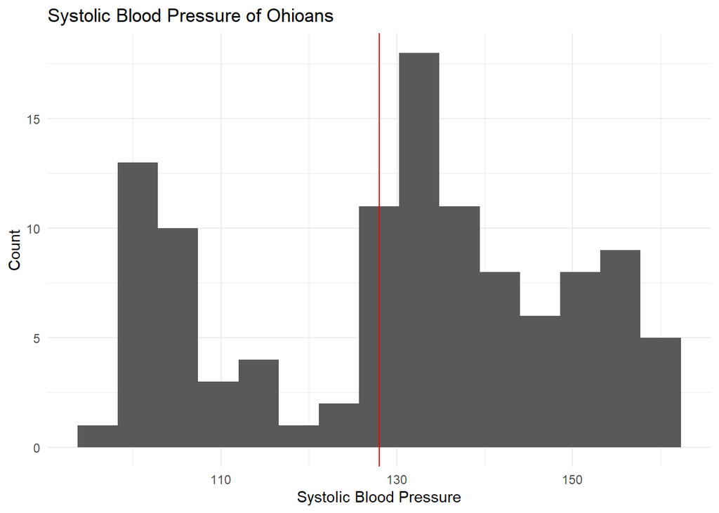

```r
pressure %>%
  ggplot(aes(x = systolic)) +
  geom_histogram(bins = 15) +
   geom_vline(xintercept = 128,
              color = "red") +
  theme_minimal() +
  labs(title = "Systolic Blood Pressure of Ohioans",
       y = 'Count',
       x = "Systolic Blood Pressure")
```

```r
 t.test(pressure$systolic,
       mu = 128)
```

```
    One Sample t-test

data:  pressure$systolic
t = 1.3674, df = 109, p-value = 0.1743
alternative hypothesis: true mean is not equal to 128
95 percent confidence interval:
 126.9091 133.9455
sample estimates:
mean of x
 130.4273
```

The p-value of $0.1743$ supports the null hypothesis. This suggests that the average systolic blood pressure of Ohioans is consistent with the average systolic blood pressure of all Americans.

## Problem 3

> Is there evidence that acceptance rate (the fraction of applications accepted) is a statistically significant explainer of graduation rate? Test at level $\alpha = 0.5$, following all standards and best-practices from class.

$H_0$: There is **not** a linear relationship between acceptance rate and graduation rate.

$H_a$: There is a linear relationship between acceptance rate and graduation rate.

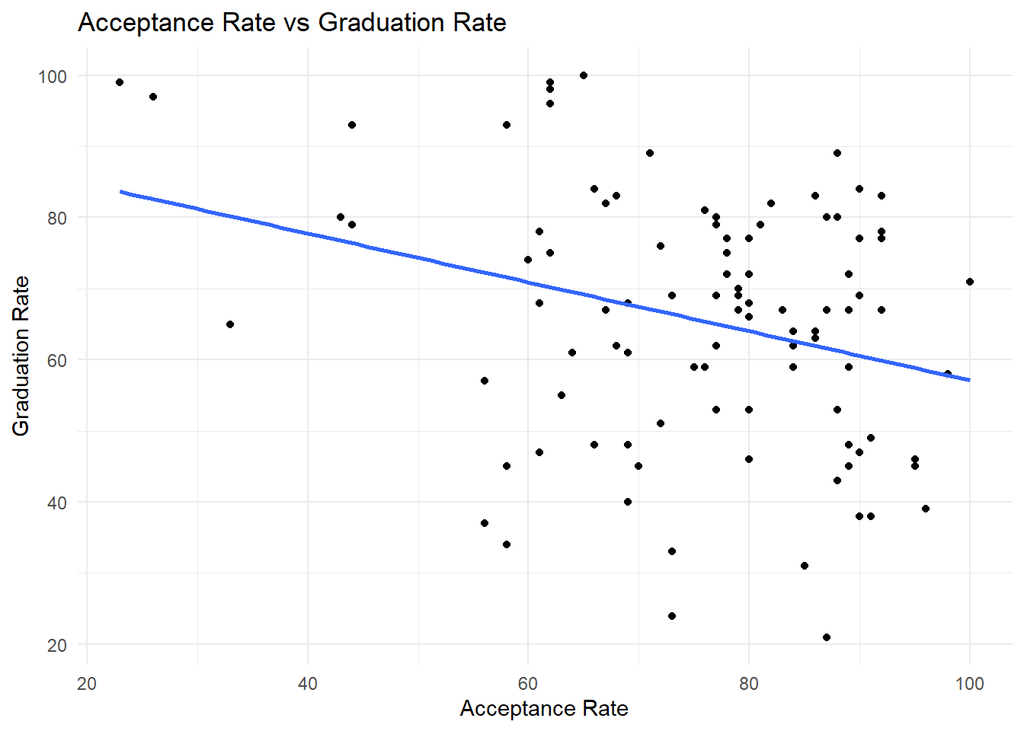

```r
college <- college %>%
  mutate(Accept.Rate = round(Accept/Apps, 2) * 100)

college %>%
  ggplot(aes(x = Accept.Rate,
             y = Grad.Rate)) +
  geom_point() +
  geom_smooth(method = "lm",
              se = FALSE) +
  theme_minimal() +
  labs(title = "Acceptance Rate vs Graduation Rate",
       x = "Acceptance Rate",
       y = "Graduation Rate")
```

```r
accept_grad_lm <- lm( Grad.Rate ~ Accept.Rate,
                      data = college)

summary(accept_grad_lm)
```

```
Call:
lm(formula = Grad.Rate ~ Accept.Rate, data = college)

Residuals:
   Min     1Q Median     3Q    Max
-42.42 -12.86   2.62  13.89  30.82

Coefficients:
            Estimate Std. Error t value Pr(>|t|)
(Intercept)  91.5509     8.7971  10.407   <2e-16 ***
Accept.Rate  -0.3443     0.1143  -3.012   0.0033 **
---
Signif. codes:  0 '***' 0.001 '**' 0.01 '*' 0.05 '.' 0.1 ' ' 1

Residual standard error: 17.07 on 98 degrees of freedom
Multiple R-squared:  0.08471,   Adjusted R-squared:  0.07537
F-statistic:  9.07 on 1 and 98 DF,  p-value: 0.003305
```

## Problem 4

> Obtain a parallel-slopes model for graduation rate using acceptance rate and public/private as explainers. Write the model equation, clearly explaining the meaning of each coefficient. Include a relevant plot. What graduation rate does this model predict for a private college with acceptance rate of 85%?

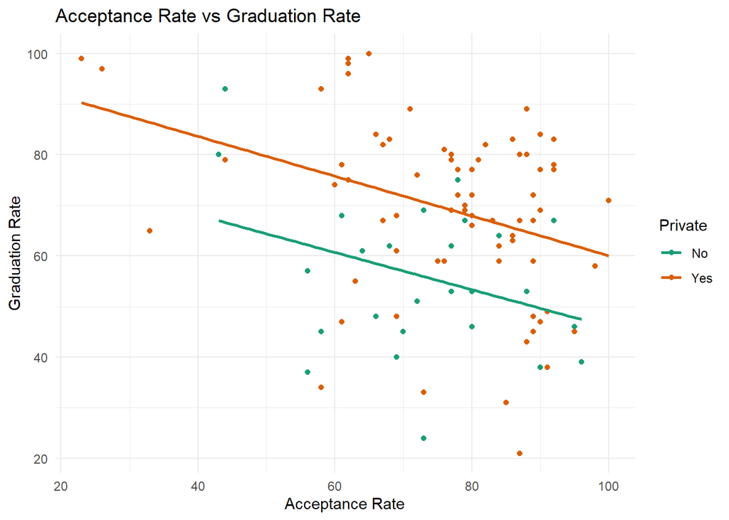

```r
college %>%
  ggplot(aes(x = Accept.Rate,
             y = Grad.Rate,
             color = Private)) +
  geom_point() +
  geom_smooth(method = "lm",
              se = FALSE) +
  theme_minimal() +
  labs(title = "Acceptance Rate vs Graduation Rate",
       x = "Acceptance Rate",
       y = "Graduation Rate") +
  scale_color_brewer(palette = "Dark2")
```

```r
accept_grad_para <- lm( Grad.Rate ~ Accept.Rate + Private,
                      data = college)

summary(accept_grad_para)
```

```
Call:
lm(formula = Grad.Rate ~ Accept.Rate + Private, data = college)

Residuals:
    Min      1Q  Median      3Q     Max
-44.230  -8.638   1.631  11.463  26.252

Coefficients:
            Estimate Std. Error t value Pr(>|t|)
(Intercept)  84.1912     8.3335  10.103  < 2e-16 ***
Accept.Rate  -0.3872     0.1063  -3.642 0.000437 ***
PrivateYes   14.7246     3.5352   4.165 6.75e-05 ***
---
Signif. codes:  0 '***' 0.001 '**' 0.01 '*' 0.05 '.' 0.1 ' ' 1

Residual standard error: 15.8 on 97 degrees of freedom
Multiple R-squared:  0.2236,    Adjusted R-squared:  0.2076
F-statistic: 13.97 on 2 and 97 DF,  p-value: 4.675e-06
```

The equation of the parallel slopes regression line is Grad.Rate $= 84.1912 - 0.3872$(`Accept.Rate`)$+14.7246$(`PrivateYes`) where `PrivateYes` is 1 if the college is private and 0 is the college is public. This predicts that a private college with an acceptance rate of 85% will have a graduation rate of 66%.

## Problem 5

> Following all best-practices from our data project and other work, identify an interesting pattern and investigate it. This analysis should include ~150 words of text, two attractive visualizations, a table, and at least one relevant outside link (as a footnote) beyond the source of the data. As part of your work, pick one song and consider its relationship to the others, pointing it out in at least one of your plots. Other than the `annotate` function, do not use syntax from outside of class in your work.

Artist’s who write their own songs are often more popular. Audiences feel like they are more connected to the artist and artist feel they have more control over their work.[^2] How is this reflected in chart topping songs?

Taylor Swift is a good example of an artist who gained popularity for writing her own songs. I am not the biggest Taylor Swift fan however I remember how often Shake It Off was played, and how before playing it radio hosts would like about how she wrote it about the media attention she was getting.[^3]

```r
billboard <- billboard %>%
  select(song,
         artist,
         date,
         weeks_at_number_one,
         songwriters,
         artist_is_a_songwriter,
         artist_is_only_songwriter
         ) %>%
  mutate(date = as.numeric(substr(date, 1, 4)),
         artist_is_a_songwriter = as.logical(artist_is_a_songwriter),
         artist_is_only_songwriter = as.logical(artist_is_only_songwriter))
```

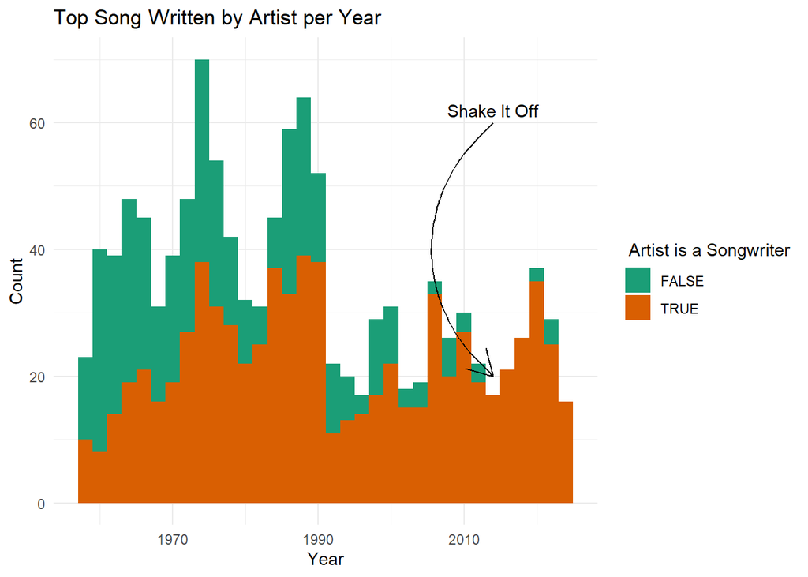

```r
billboard %>%
  ggplot(aes(x = date,
             fill = artist_is_a_songwriter)) +
  geom_histogram(binwidth = 2) +
  theme_minimal() +
  scale_fill_brewer(palette = "Dark2") +

    labs(x = "Year",
       y = "Count",
       fill = " Artist is a Songwriter",
       title = "Top Song Written by Artist per Year") +
  annotate(geom = "text",
           x = 2014,
           y = 62,
           label = "Shake It Off",
           xmin = 2005,
           xmax = 2015) +
  annotate(geom = "curve",
           x = 2014,
           y = 60,
           xend = 2014,
           yend = 20,
           arrow = arrow())
```

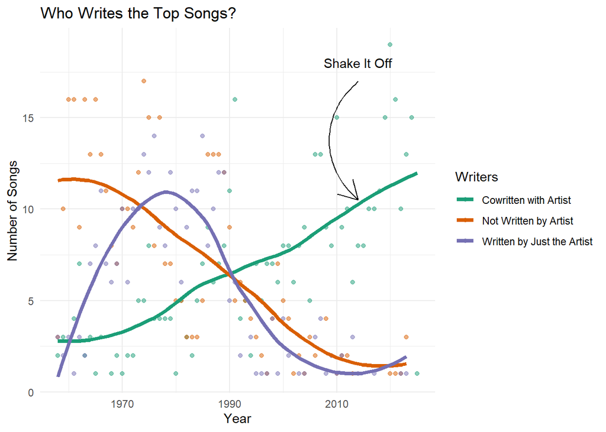

```r
billboard %>%
  summarize(date,
            songwriter = case_when(
              artist_is_only_songwriter & artist_is_only_songwriter ~ "Written by Just the Artist",
              artist_is_a_songwriter & !artist_is_only_songwriter ~ "Cowritten with Artist",
              .default = "Not Written by Artist"
            )) %>%
  group_by(date,
           songwriter) %>%
  summarise(count = n()) %>%
  ungroup() %>%
  ggplot(aes(x = date,
             y = count,
             color = songwriter)) +
  geom_point(alpha = 0.5) +
  geom_smooth(se = FALSE,
             linewidth = 1.5) +
  theme_minimal() +
  scale_color_brewer(palette = "Dark2") +
  labs(title = "Who Writes the Top Songs?",
       x = "Year",
       y = "Number of Songs",
       color = "Writers") +
  annotate(geom = "text",
           x = 2014,
           y = 18,
           label = "Shake It Off",
           xmin = 2003,
           xmax = 2015) +
  annotate(geom = "curve",
           x = 2014,
           y = 17,
           xend = 2014,
           yend = 10.5,
           arrow = arrow())
```

Over time, more artist have helped write their own songs but less artists have been the sole writer of their own songs. Two immediate causes come to mind.

1. The music industry realized that audiences prefer when artist write their own songs and startted attributing more music to their artists (no matter how much or how little they wrote)
2. More people who actually helped write songs got the credit they deserved for writing

Drawing any conclusions would require further investigations outside of this project.

Despite have many popular songs that she wrote herself[^4], all of Taylor Swift’s chart topping songs were co written.

```r
billboard %>%
  filter(artist == "Taylor Swift") %>%
  select(Year = date,
         Song = song,
         Writers = songwriters,
         "Weeks at the Top" = weeks_at_number_one) %>%
  gt() %>%
  tab_header(title = "Taylor Swift Chart Topping Songs",
             subtitle = "All are made in collaborative with other writers")
```

Taylor Swift Chart Topping Songs

All are made in collaborative with other writers

| Year | Song | Writers | Weeks at the Top |
| --- | --- | --- | --- |
| 2012 | We Are Never Ever Getting Back Together | Max Martin;Shellback;Taylor Swift | 3 |
| 2014 | Shake It Off | Max Martin;Shellback;Taylor Swift | 4 |
| 2014 | Blank Space | Max Martin;Shellback;Taylor Swift | 7 |
| 2017 | Look What You Made Me Do | Fred Fairbrass;Richard Fairbrass;Rob Manzoli;Jack Antonoff;Taylor Swift | 3 |
| 2020 | cardigan | Aaron Dressner;Taylor Swift | 1 |
| 2020 | willow | Taylor Swift;Aaron Dressner | 1 |
| 2021 | All Too Well (10 Minute Version) | Taylor Swift;Liz Rose | 1 |
| 2022 | Anti-Hero | Taylor Swift;Jack Antonoff | 8 |
| 2023 | Cruel Summer | Jack Antonoff;St. Vincent;Taylor Swift | 4 |
| 2023 | Is It Over Now? | Taylor Swift;Jack Antonoff | 1 |

I think this show collaborative the process or making music can be, that an artist’s most popular songs where made with other people.

## Problem 6

> Create a new GitHub repo that includes only your findings from problem 5. This will entail creating a new project and smaller standalone .qmd document. Include a clickable link to this repo in the work that you submit via moodle.

[My Github](https://github.com/IlanaB11/My-TidyTuesday/tree/main)

## Footnotes

[^1]: [TidyTuesday Github](https://github.com/rfordatascience/tidytuesday/tree/main/data/2025/2025-08-26)
[^2]: [Songwriting in Pop Music](https://machronicle.com/the-era-of-songwriting-in-pop-music/)
[^3]: [What is Shake It Off by Taylor Swift About](https://en.wikipedia.org/wiki/Shake_It_Off)
[^4]: [Songs Written By Taylor Swift](https://www.businessinsider.com/taylor-swift-solo-written-songs)